# Отчёт по модулю 3 курса ‘Stepik Введение в Linux’

Дисциплина: Операционные системы

Мацюк Константин Владимирович

Российский университет дружбы народов

2026

## Содержание (1)

- Цель работы
- Задание
- Текстовый редактор vim
- Скрипты на bash: основы
- Скрипты на bash: ветвления и циклы

## Содержание (2)

- Скрипты на bash: разное
- Продвинутый поиск и редактирование
- Строим графики в gnuplot
- Разное
- Выводы

# Цель работы

Пройти курс «Введение в Linux» (модуль 3).

# Задание

Выполнить модуль 3.

# Текстовый редактор vim

Для выхода из редактора vim после открытия файла нужно нажать клавишу `:`, затем `q` и `Enter`.

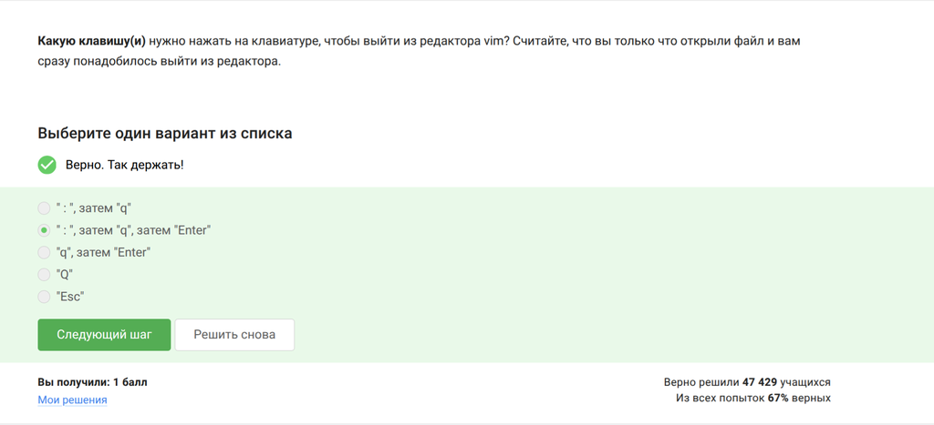

Выход из редактора vim

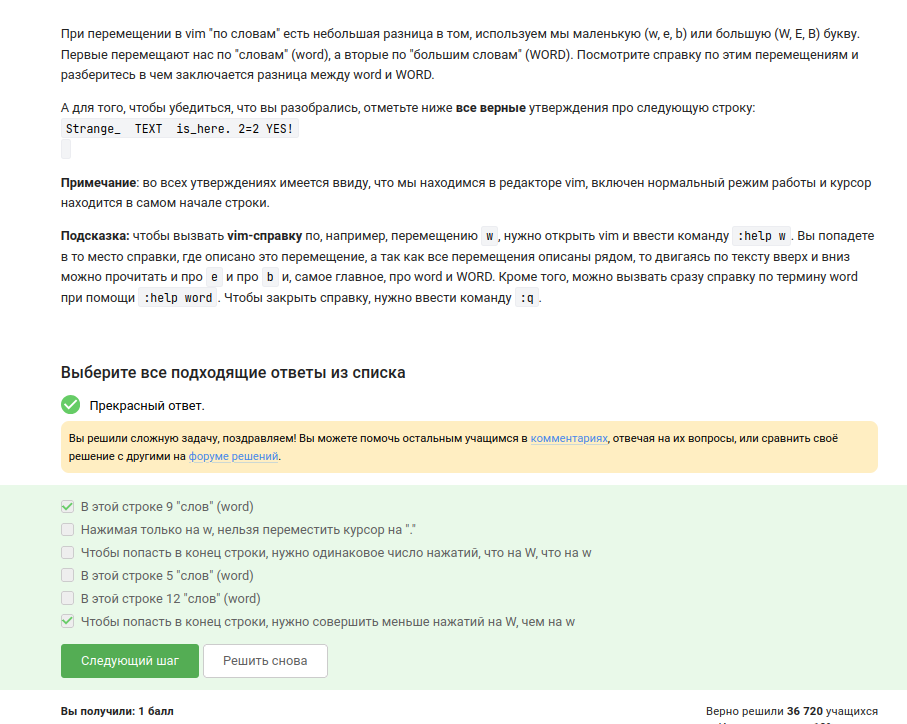

Различие между word и WORD

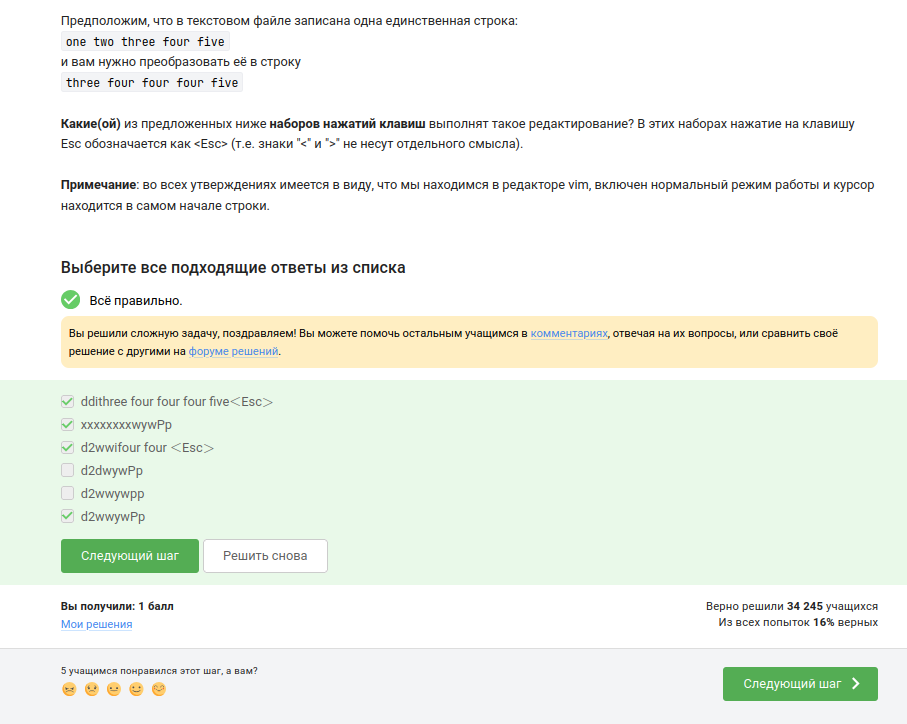

Преобразование строки в vim

`:%s/Windows/Linux/` выполняет глобальную замену первого вхождения.

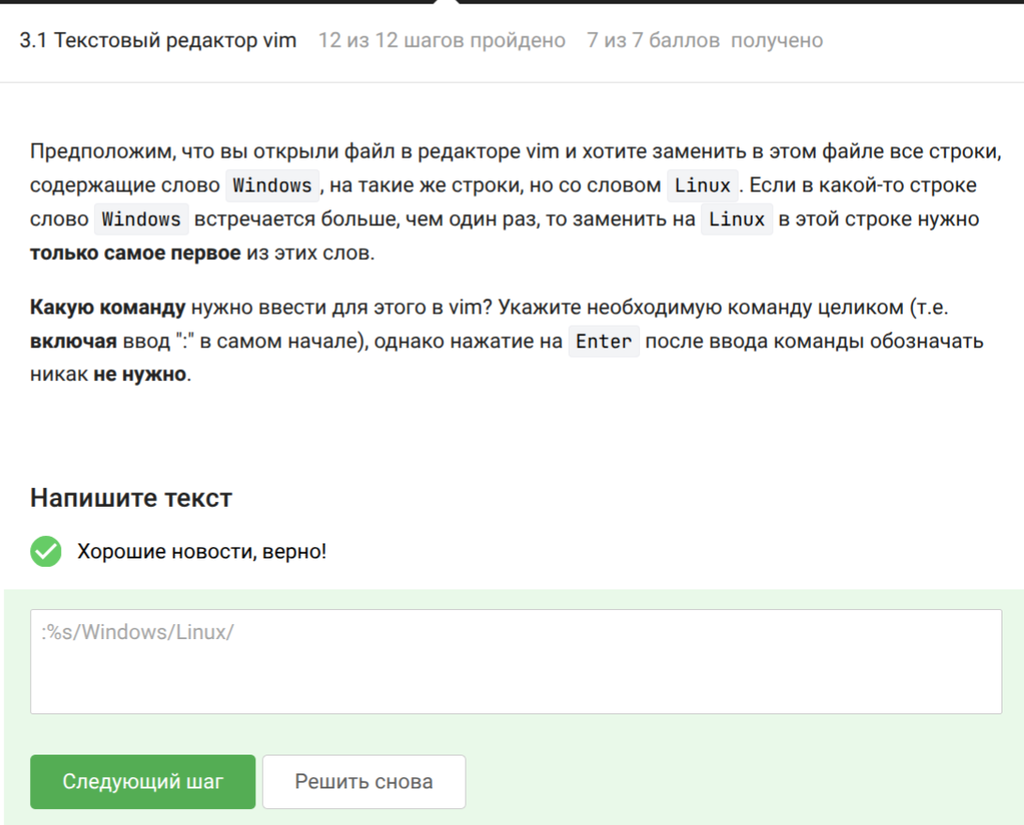

Глобальная замена в vim

В режиме Visual доступны команды перемещения, а также команды `d` (удалить) и `y` (скопировать).

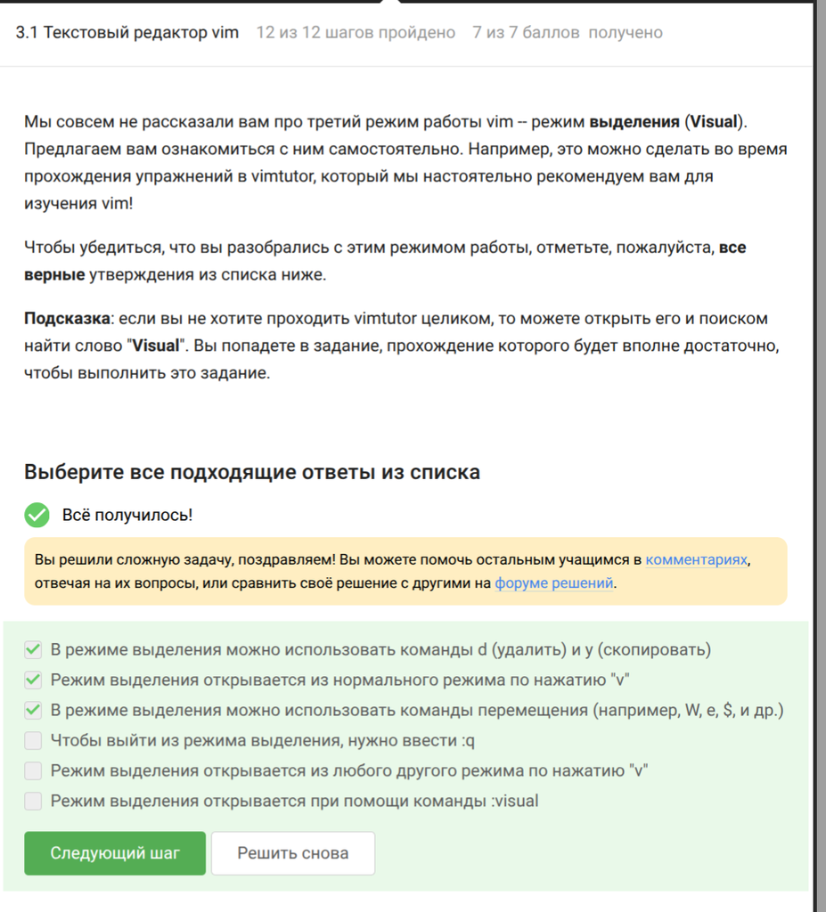

Команды в режиме Visual

# Скрипты на bash: основы

Каждая оболочка bash имеет свою собственную историю команд. Во вложенной оболочке будут доступны только команды, введённые в ней (набор C).

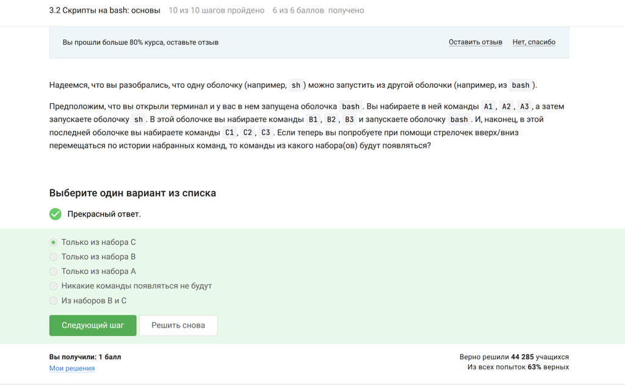

История команд во вложенной оболочке

Скрипт сначала переходит в `/home/bi/`, затем создаёт файл `file1.txt`. Абсолютный путь к созданному файлу – `/home/bi/file1.txt`.

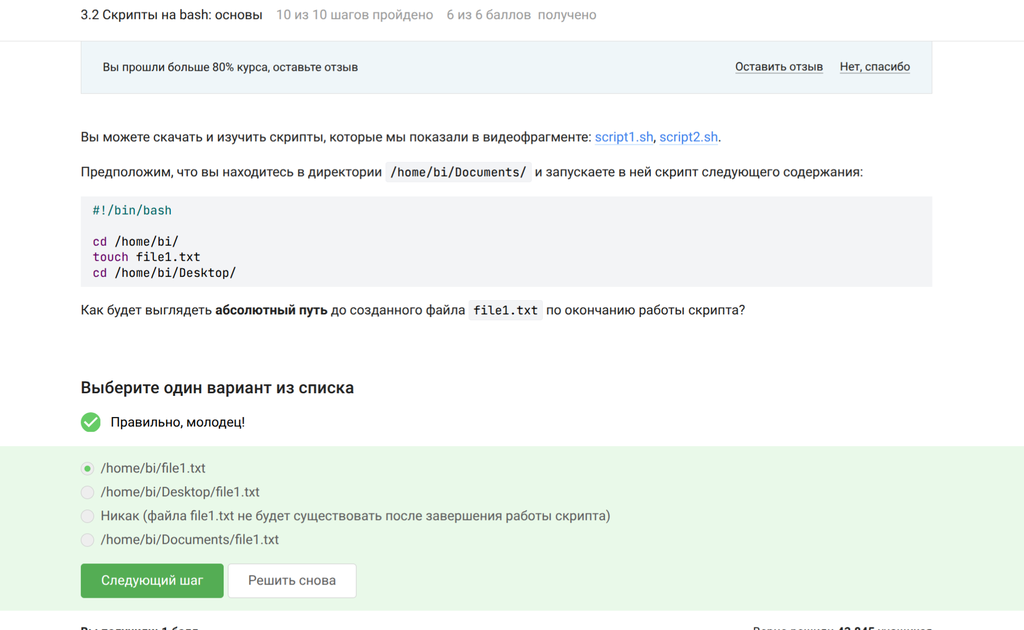

Определение абсолютного пути к файлу

Скрипт выводит строку с подстановкой аргументов. Знак доллара перед `$1` экранируется, чтобы напечатать литерал. При запуске `./script.sh one two` на экране появится `Arguments are: $1=one $2=two`.

[figure not shown]

Скрипт на bash, часть 1

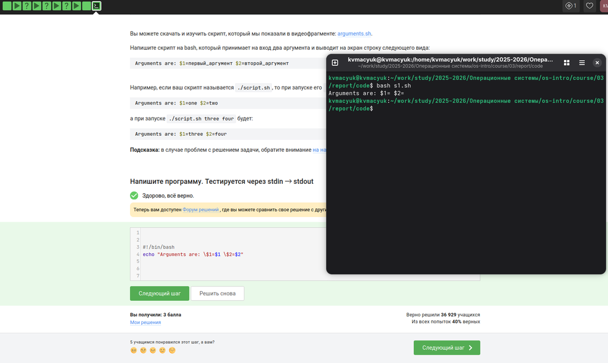

Скрипт на bash, часть 2

# Скрипты на bash: ветвления и циклы

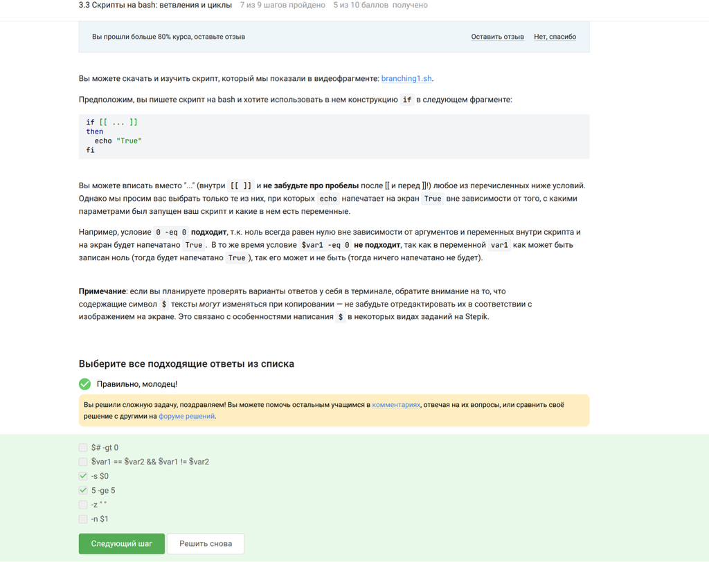

Всегда истинные условия

При `var=3` и `var=5` ни одно из условий не выполняется, поэтому оба раза будет напечатано «four».

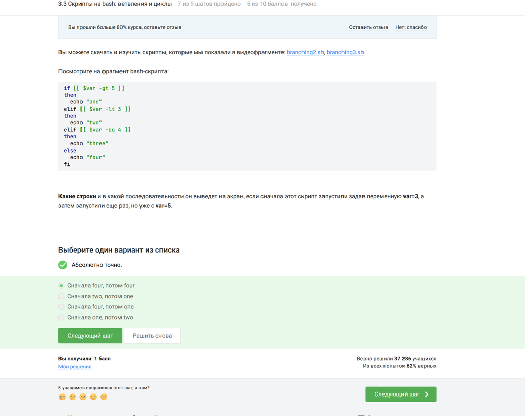

Анализ условного оператора

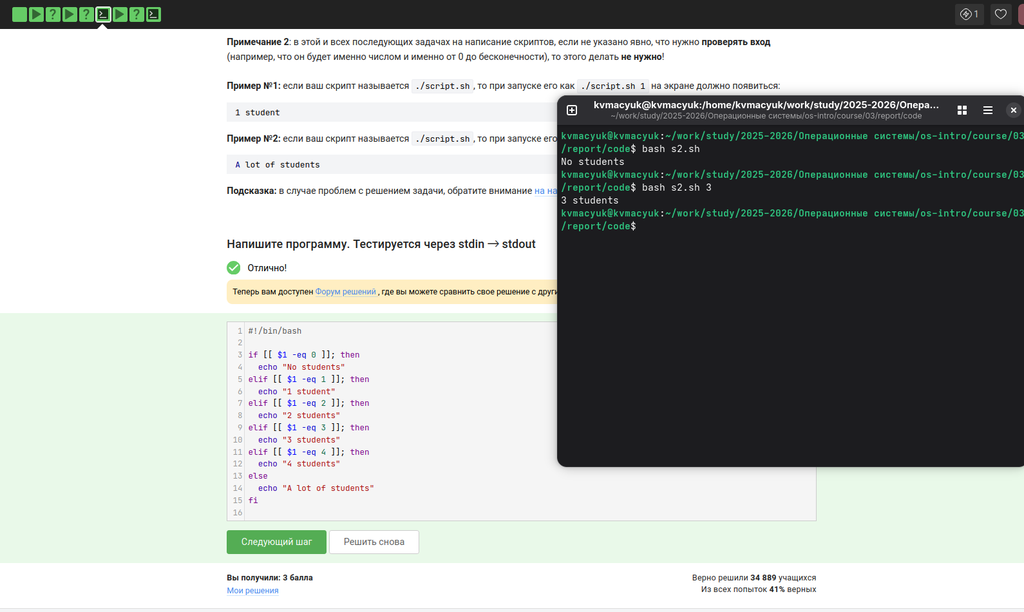

Скрипт анализа количества студентов

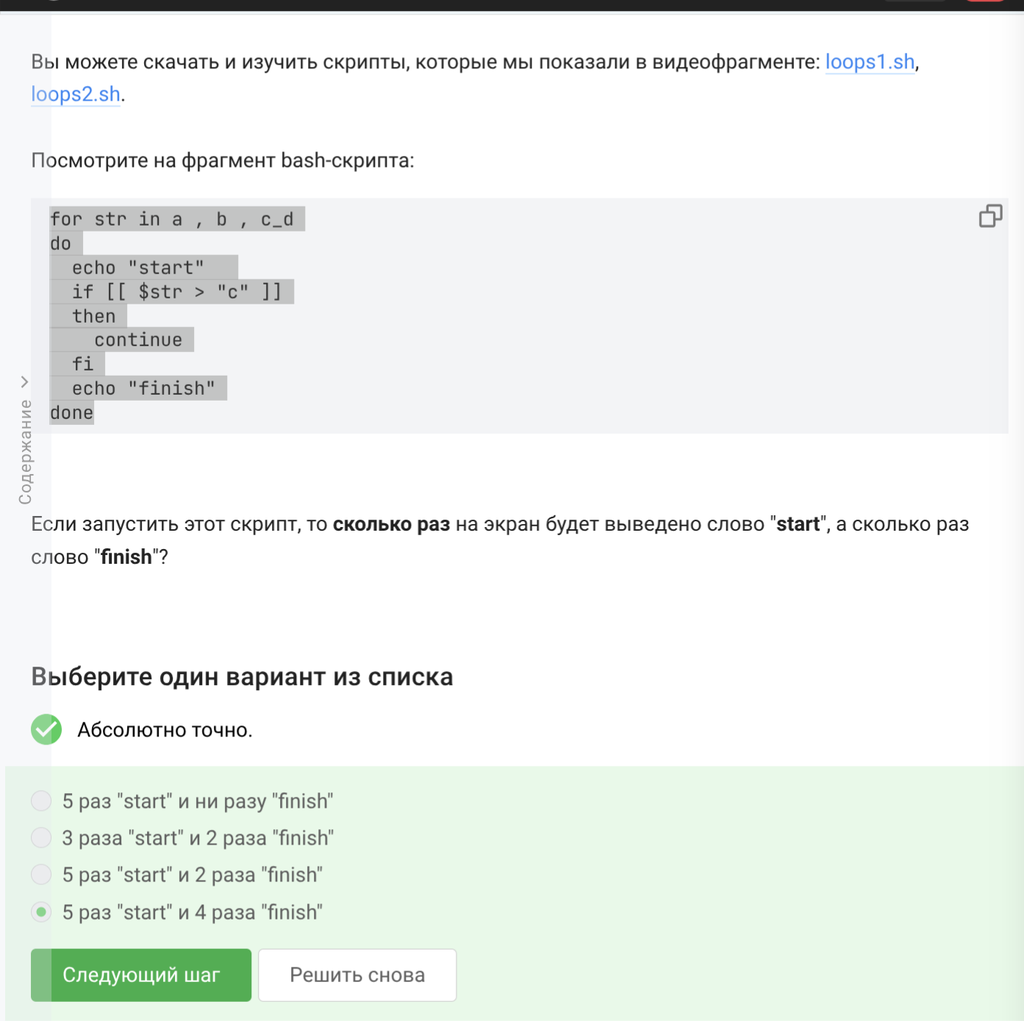

Цикл for с командой continue

Скрипт в бесконечном цикле читает имя и возраст. Если имя пустое или возраст равен 0, выводится «bye» и цикл прерывается. Иначе определяется возрастная группа.

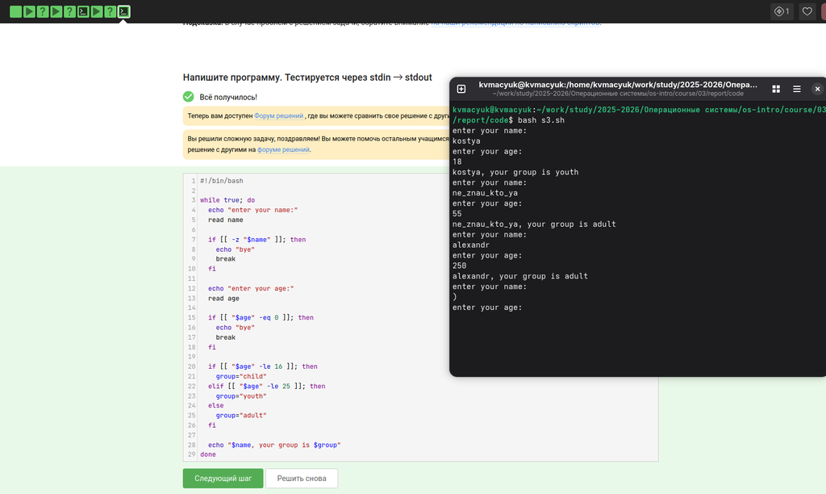

Бесконечный цикл с чтением данных

# Скрипты на bash: разное

Команда `let` выполняет арифметические операции.

[figure not shown]

Использование команды let

Обратные кавычки выполняют команду `pwd`. После `cd /home/bi/` текущим становится `/home/bi`, поэтому `echo` выводит `/home/bi`.

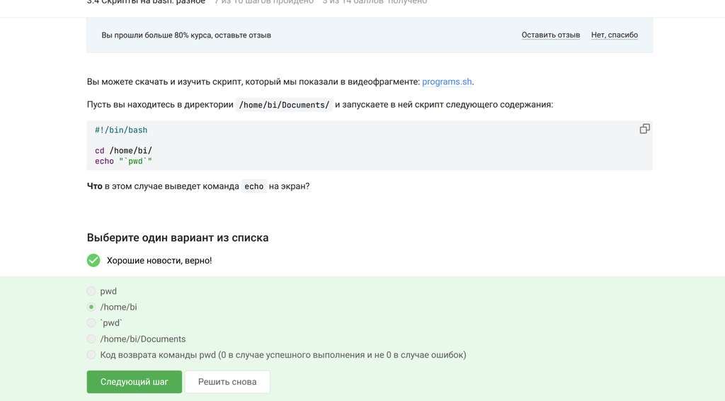

Вывод текущего каталога через обратные кавычки

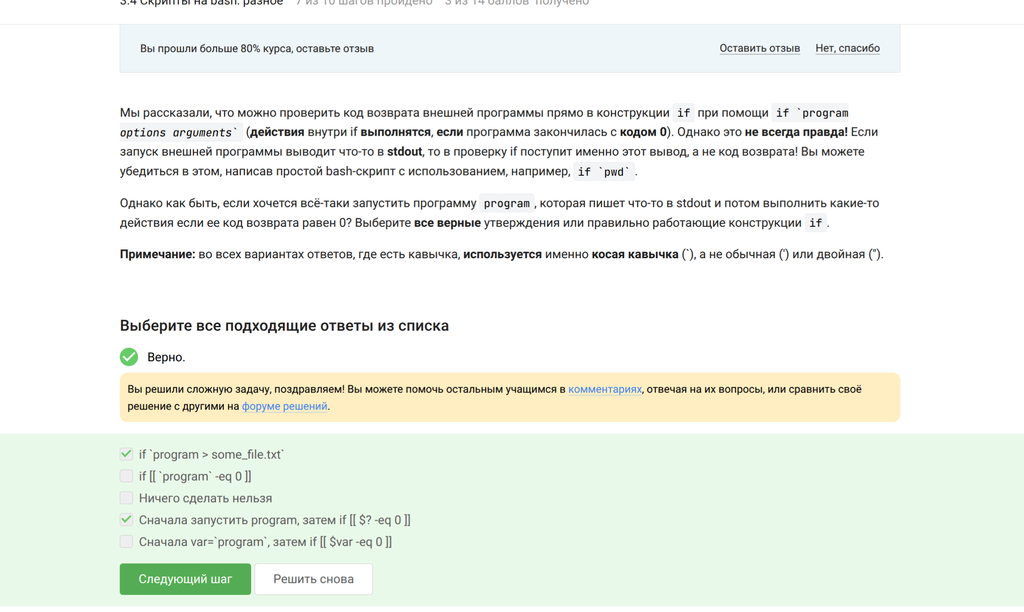

Проверка кода возврата программы

В функции `counter` переменная `c1` объявлена как `local`, поэтому не сохраняет значение. `c2` накапливает сумму: после десяти вызовов `echo` выводит «counters are and 110».

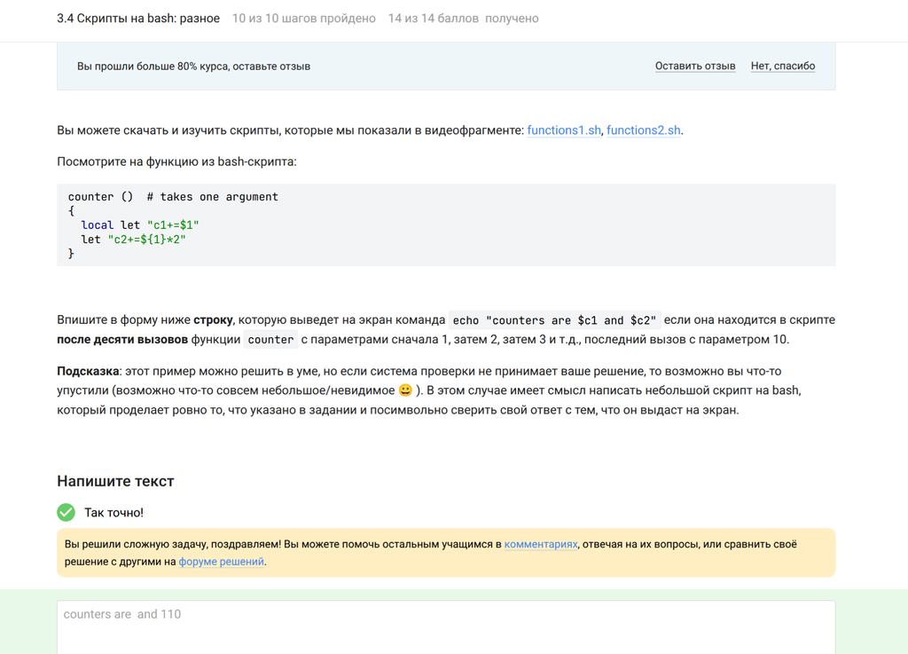

Функция counter и области видимости переменных

Функция `gcd` реализует алгоритм Евклида. Основная программа читает пары чисел и вызывает `gcd`. При пустой строке выводится «bye» и выполнение прекращается.

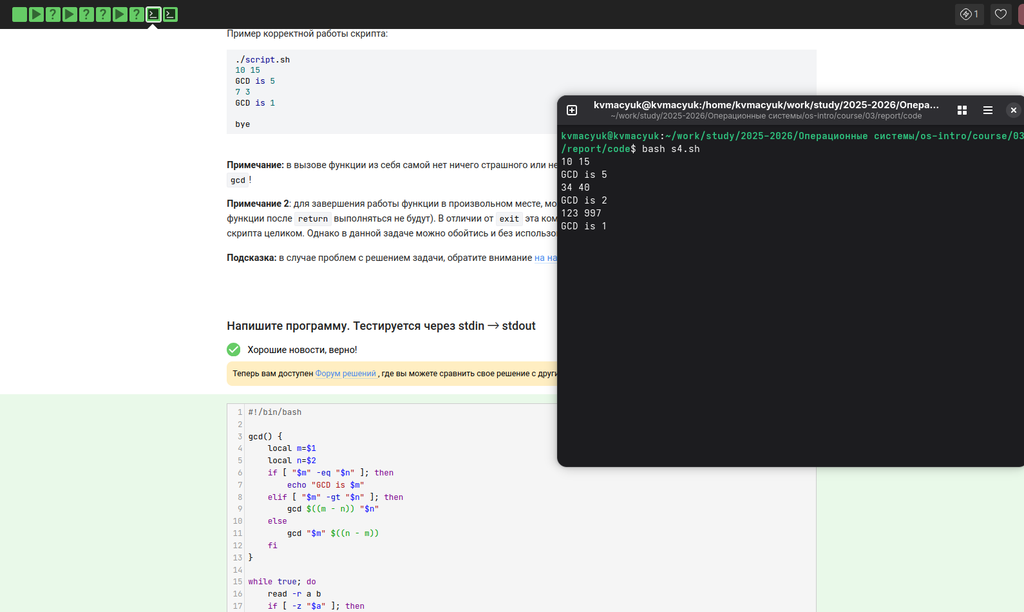

Реализация алгоритма Евклида

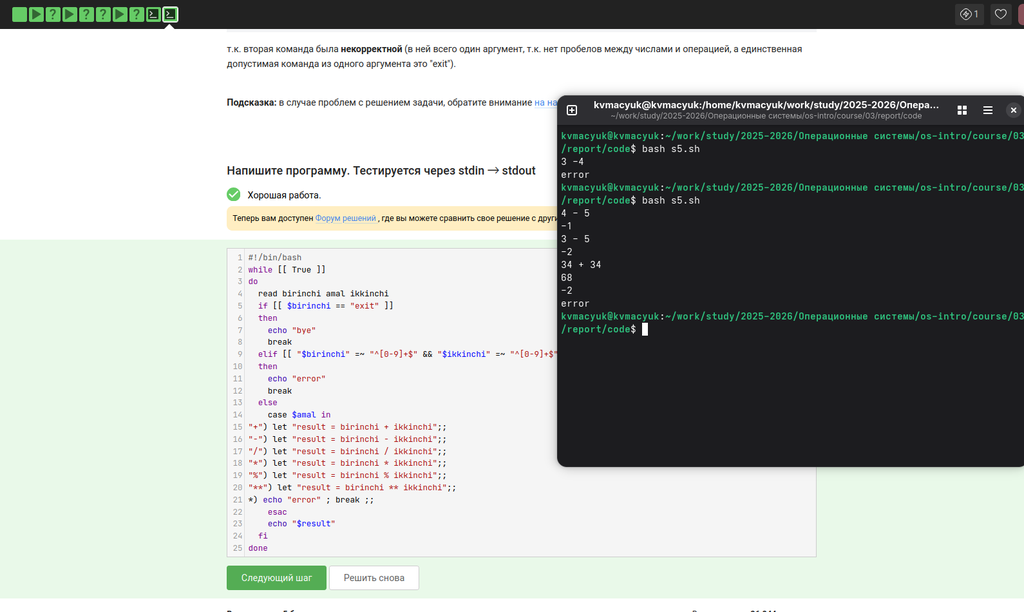

Калькулятор с обработкой ошибок

# Продвинутый поиск и редактирование

Опция `-iname` игнорирует регистр. Команда `find -iname "star*"` найдёт все четыре файла, начинающихся на Star/STAR/star.

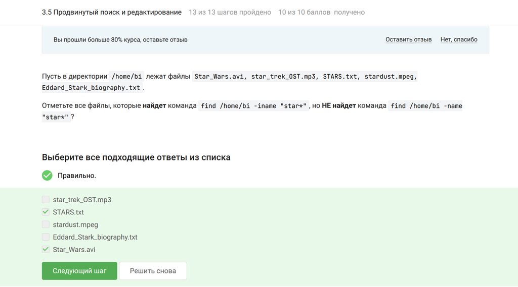

Поиск файлов с игнорированием регистра

Опции `-path` и `-name` отличаются: `-path` сопоставляет весь путь, а `-name` только имя файла. Утверждение «Если заменить `-name` на `-path`, результат поиска иногда может остаться таким же» верно.

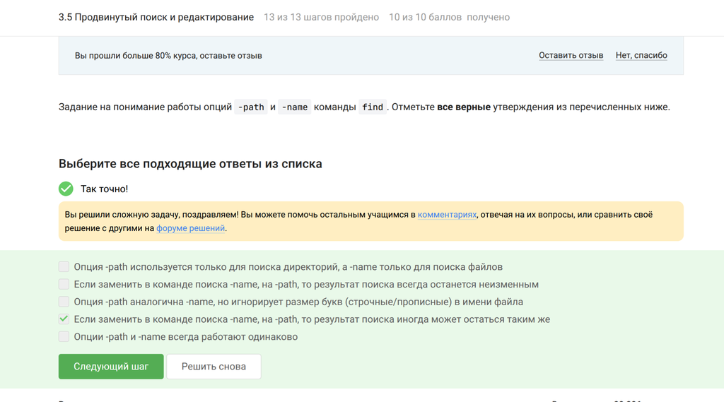

Сравнение опций -path и -name

Все варианты `grep` выводят одинаковое количество строк, так как каждая строка файла содержит искомое слово. В итоге все команды создадут файл `results.txt` одинакового размера.

[figure not shown]

Сравнение вывода grep с разными опциями

Регулярное выражение ищет строки, заканчивающиеся определённым образом.

[figure not shown]

Использование регулярных выражений

Без опции `-n` `sed` печатает каждую строку по умолчанию, а команда `p` — ещё раз. Строки, соответствующие шаблону, будут выведены дважды, остальные — один раз.

[figure not shown]

Дублирование строк в sed

[figure not shown]

Замена по шаблону в sed

# Строим графики в gnuplot

Опция `-p` (`--persist`) при запуске gnuplot предотвращает закрытие окон с графиками после завершения работы программы.

[figure not shown]

Использование опции persist в gnuplot

При использовании `set key autotitle columnhead` и отсутствии заголовков, название ряда берётся из первого значения второго столбца. Всего будет нарисовано 9 точек, так как первая строка использована для названия.

[figure not shown]

Автоматическое определение заголовка в gnuplot

Команда `set xtics` создаёт пользовательские деления на оси X с помощью конкатенации строк.

[figure not shown]

Создание пользовательских делений на оси X

[figure not shown]

Модификация анимации графика